# Customer Purchasing Behavior Analysis

```python
import pandas as pd
import numpy as np
import seaborn as sns
import matplotlib.pyplot as plt

data=pd.read_csv(r'file:///C:\Users\GREAT\Desktop\Market.csv')
```

```python
data
```

|  | ID | Year_Birth | Education | Marital_Status | Salary | Kidhome | Teenhome | Dt_Customer | Month | last_pur_days | ... | Meat sales | Fish_Sales | Sweet_sales | Gold_sales | NumWebPurchases | NumCatalogPurchases | NumStorePurchases | NumWebVisitsMonth | Country | Complain |
| --- | --- | --- | --- | --- | --- | --- | --- | --- | --- | --- | --- | --- | --- | --- | --- | --- | --- | --- | --- | --- | --- |
| 0 | 1826 | 1970 | Graduation | Divorced | 84835.0 | 0 | 0 | 6/16/2014 | June | 0 | ... | 379 | 111 | 189 | 218 | 4 | 4 | 6 | 1 | Spain | 0 |
| 1 | 1 | 1961 | Graduation | Single | 57091.0 | 0 | 0 | 6/15/2014 | June | 0 | ... | 64 | 7 | 0 | 37 | 7 | 3 | 7 | 5 | Canada | 0 |
| 2 | 10476 | 1958 | Graduation | Married | 67267.0 | 0 | 1 | 5/13/2014 | May | 0 | ... | 59 | 15 | 2 | 30 | 3 | 2 | 5 | 2 | USA | 0 |
| 3 | 1386 | 1967 | Graduation | Together | 32474.0 | 1 | 1 | 5/11/2014 | May | 0 | ... | 1 | 0 | 0 | 0 | 1 | 0 | 2 | 7 | Australia | 0 |
| 4 | 5371 | 1989 | Graduation | Single | 21474.0 | 1 | 0 | 4/8/2014 | April | 0 | ... | 24 | 11 | 0 | 34 | 3 | 1 | 2 | 7 | Spain | 0 |
| ... | ... | ... | ... | ... | ... | ... | ... | ... | ... | ... | ... | ... | ... | ... | ... | ... | ... | ... | ... | ... | ... |
| 2235 | 10142 | 1976 | PhD | Divorced | 66476.0 | 0 | 1 | 3/7/2013 | March | 99 | ... | 126 | 47 | 48 | 78 | 5 | 2 | 11 | 4 | USA | 0 |
| 2236 | 5263 | 1977 | 2n Cycle | Married | 31056.0 | 1 | 0 | 1/22/2013 | January | 99 | ... | 13 | 3 | 8 | 16 | 1 | 0 | 3 | 8 | Spain | 0 |
| 2237 | 22 | 1976 | Graduation | Divorced | 46310.0 | 1 | 0 | 12/3/2012 | December | 99 | ... | 88 | 15 | 5 | 14 | 6 | 1 | 5 | 8 | Spain | 0 |
| 2238 | 528 | 1978 | Graduation | Married | 65819.0 | 0 | 0 | 11/29/2012 | November | 99 | ... | 701 | 149 | 165 | 63 | 5 | 4 | 10 | 3 | India | 0 |
| 2239 | 4070 | 1969 | PhD | Married | 94871.0 | 0 | 2 | 9/1/2012 | September | 99 | ... | 553 | 188 | 0 | 144 | 8 | 5 | 4 | 7 | Canada | 0 |

2240 rows × 22 columns

Checking the null values to ensure data is clean before analysis

```python
data.isnull().sum()
```

```
ID                      0
Year_Birth              0
Education               0
Marital_Status          0
Salary                 24
Kidhome                 0
Teenhome                0
Dt_Customer             0
Month                   0
last_pur_days           0
Wine_Sales              0
Fruit_sales             0
Meat sales              0
Fish_Sales              0
Sweet_sales             0
Gold_sales              0
NumWebPurchases         0
NumCatalogPurchases     0
NumStorePurchases       0
NumWebVisitsMonth       0
Country                 0
Complain                0
dtype: int64
```

filling the null value with the mean of the column

```python
data.fillna(data['Salary'].mean(),inplace=True)
```

Checking the numbers of rows and columns in the dataset

```python
data.shape
```

```
(2240, 22)
```

Visualizing the dataset using heatmap from seaborn library to see if there is any correlated data in the dataset

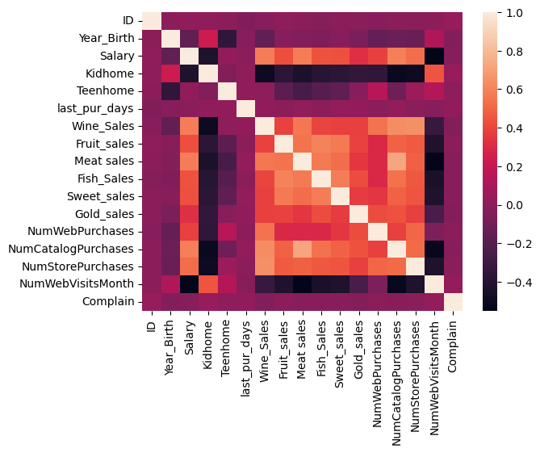

```python
sns.heatmap(data.corr())
```

Creating a new column to Calculate the age of each customer

```python
data['Age'] = 2013 - data['Year_Birth']
```

Checking the age distribution of the customers from the newly created column,majority of the customers are within the age group of 30-60

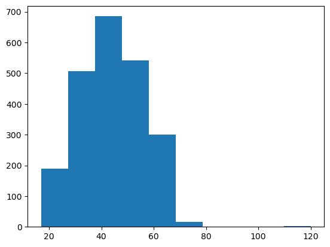

```python
plt.hist(data['Age'],bins=10)
```

The information of the first set of company customer,they were all from Spain

```python
data['Dt_Customer'].min()
data[(data.Dt_Customer=='1/1/2013')]
```

|  | ID | Year_Birth | Education | Marital_Status | Salary | Kidhome | Teenhome | Dt_Customer | Month | last_pur_days | ... | Fish_Sales | Sweet_sales | Gold_sales | NumWebPurchases | NumCatalogPurchases | NumStorePurchases | NumWebVisitsMonth | Country | Complain | Age |
| --- | --- | --- | --- | --- | --- | --- | --- | --- | --- | --- | --- | --- | --- | --- | --- | --- | --- | --- | --- | --- | --- |
| 203 | 7261 | 1971 | Graduation | Together | 34600.0 | 1 | 1 | 1/1/2013 | January | 8 | ... | 8 | 3 | 15 | 5 | 2 | 5 | 8 | Spain | 0 | 42 |
| 204 | 2452 | 1971 | Graduation | Together | 34600.0 | 1 | 1 | 1/1/2013 | January | 8 | ... | 8 | 3 | 15 | 5 | 2 | 5 | 8 | Spain | 0 | 42 |
| 1744 | 10637 | 1964 | Graduation | Married | 40800.0 | 1 | 2 | 1/1/2013 | January | 77 | ... | 8 | 30 | 10 | 3 | 0 | 3 | 7 | Spain | 1 | 49 |
| 1999 | 8162 | 1956 | Master | Together | 14661.0 | 0 | 0 | 1/1/2013 | January | 88 | ... | 6 | 2 | 2 | 1 | 0 | 3 | 6 | Spain | 0 | 57 |

4 rows × 23 columns

Creating new column to calculate the total number of children by each customer

```python
data['Total_Children'] = data['Kidhome'] + data['Teenhome']
data[['Total_Children']]
```

|  | Total_Children |
| --- | --- |
| 0 | 0 |
| 1 | 0 |
| 2 | 1 |
| 3 | 2 |
| 4 | 1 |
| ... | ... |
| 2235 | 1 |
| 2236 | 1 |
| 2237 | 1 |
| 2238 | 0 |
| 2239 | 2 |

2240 rows × 1 columns

Checking to see if there is any correlation between the salary and total number of children by each customer,the analysis show very weak correlation between the two variables

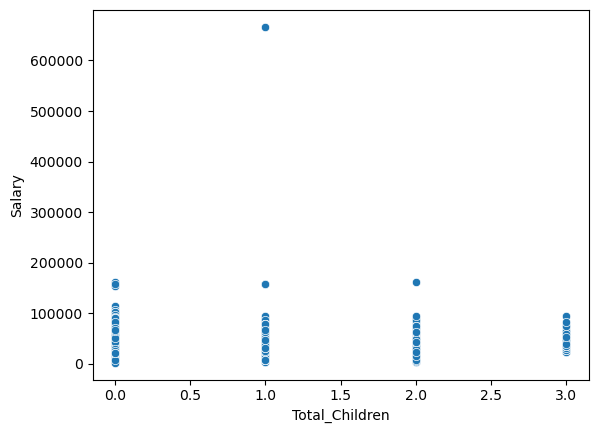

```python
sns.scatterplot(x='Total_Children',y='Salary',data=data)
```

The avaerage salary of the customer

```python
data['Salary'].mean()
```

```
52247.25135379059
```

Checking to see if the salary is determine by the level of education

```python
data.groupby('Education')['Salary'].sum().sort_values(ascending=False)
```

```
Education
Graduation    5.941066e+07
PhD           2.726713e+07
Master        1.957614e+07
2n Cycle      9.683380e+06
Basic         1.096538e+06
Name: Salary, dtype: float64
```

Creating a new column to calculate the total sales by each customer

```python
data['Total_sales'] = data['Fish_Sales'] +data['Sweet_sales'] +data['Gold_sales']
+ data['Wine_Sales'] + data['Fruit_sales'] +data['Meat sales']
```

Checking to see if the level of customer salary influence their purchasing habit by checking the reltionship between salary and total purchase by each customer.

The analysis shown there is relationship between the two variables.The scatter plot shown increase in the number of sales as the salary increases.

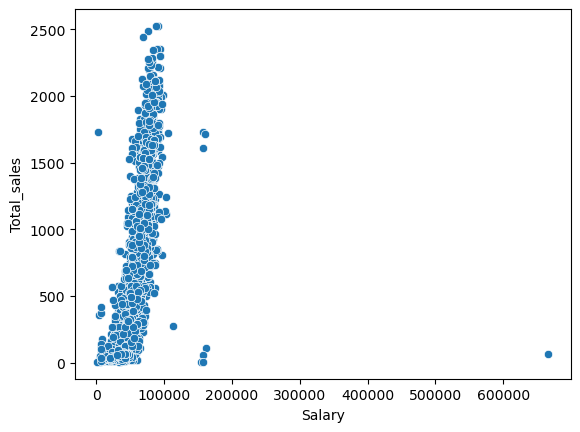

```python
data['Salary'].corr(data['Total_sales'])
sns.scatterplot(x='Salary',y='Total_sales',data=data)
```

Total columns after creation of additional columns

```python
data.columns
```

```
Index(['ID', 'Year_Birth', 'Education', 'Marital_Status', 'Salary', 'Kidhome',
       'Teenhome', 'Dt_Customer', 'Month', 'last_pur_days', 'Wine_Sales',
       'Fruit_sales', 'Meat sales', 'Fish_Sales', 'Sweet_sales', 'Gold_sales',
       'NumWebPurchases', 'NumCatalogPurchases', 'NumStorePurchases',
       'NumWebVisitsMonth', 'Country', 'Complain', 'Age', 'Total_Children',
       'Total_sales'],
      dtype='object')
```

Prediction of numbers of children base on Age,Education and Salary of each customer

Creating dataset for prediction using LinearRegression from sklearn model

```python
Prediction = data[['Age','Education','Salary','Total_Children']]
Prediction
```

|  | Age | Education | Salary | Total_Children |
| --- | --- | --- | --- | --- |
| 0 | 43 | Graduation | 84835.0 | 0 |
| 1 | 52 | Graduation | 57091.0 | 0 |
| 2 | 55 | Graduation | 67267.0 | 1 |
| 3 | 46 | Graduation | 32474.0 | 2 |
| 4 | 24 | Graduation | 21474.0 | 1 |
| ... | ... | ... | ... | ... |
| 2235 | 37 | PhD | 66476.0 | 1 |
| 2236 | 36 | 2n Cycle | 31056.0 | 1 |
| 2237 | 37 | Graduation | 46310.0 | 1 |
| 2238 | 35 | Graduation | 65819.0 | 0 |
| 2239 | 44 | PhD | 94871.0 | 2 |

2240 rows × 4 columns

Importing the required libraries

```python
from sklearn.linear_model import LinearRegression
lin = LinearRegression()
from sklearn.model_selection import train_test_split
from sklearn.preprocessing import LabelEncoder
lab = LabelEncoder()
```

Model cannot understand characteristics data so the characteristics data has to be transformed to numerical data

```python
lab.fit(Prediction.Education.drop_duplicates())
Prediction.Education = lab.fit_transform(Prediction.Education)
```

The categorical data finally transformed to numerical

```python
Prediction.head(5)
```

|  | Age | Education | Salary | Total_Children |
| --- | --- | --- | --- | --- |
| 0 | 43 | 2 | 84835.0 | 0 |
| 1 | 52 | 2 | 57091.0 | 0 |
| 2 | 55 | 2 | 67267.0 | 1 |
| 3 | 46 | 2 | 32474.0 | 2 |
| 4 | 24 | 2 | 21474.0 | 1 |

Selecting the independent and dependent variable from the dataset

```python
X = Prediction.drop(['Total_Children'],axis=1)
y= Prediction ['Total_Children']
```

Spliting the dataset for training and testing purposes

```python
X_test,X_train,y_test,y_train = train_test_split(X,y,test_size = 1/3 ,random_state = 0)
```

Fiting the training sample into linear model

```python
lin.fit(X_train,y_train)
```

```
LinearRegression()
```

Prediction the test sample to predict the number of children by each customer base on the stated factors

```python
predict = lin.predict(X_test)
pre = pd.DataFrame(X_test)
pre['Total_Children'] = y_test
pre['Pridicted_Total_Children']=predict
pre
```

|  | Age | Education | Salary | Total_Children | Pridicted_Total_Children |
| --- | --- | --- | --- | --- | --- |
| 985 | 25 | 1 | 13724.0 | 1 | 1.026913 |
| 966 | 35 | 2 | 16531.0 | 1 | 1.102843 |
| 1082 | 52 | 3 | 74881.0 | 2 | 0.833893 |
| 268 | 63 | 2 | 34026.0 | 2 | 1.115794 |
| 757 | 42 | 2 | 52914.0 | 1 | 0.888313 |
| ... | ... | ... | ... | ... | ... |
| 1033 | 51 | 2 | 51195.0 | 2 | 0.942428 |
| 1731 | 35 | 3 | 35544.0 | 1 | 1.021387 |
| 763 | 50 | 3 | 33562.0 | 3 | 1.105571 |
| 835 | 37 | 2 | 59809.0 | 2 | 0.817838 |
| 1653 | 60 | 3 | 84953.0 | 0 | 0.803077 |

1493 rows × 5 columns

To check the accuracy and error related to our prediction,the lower the figure provided by the following metrics,the higher the level of the accuracy of our prediction

```python
from sklearn import metrics
print(metrics.mean_absolute_error(y_test,predict))
print(metrics.mean_squared_error(y_test,predict))
print(np.sqrt(metrics.mean_absolute_error(y_test,predict)))
```

```
0.527075136997873
0.5080784084393667
0.7259994056456748
```

The number of customers by countries

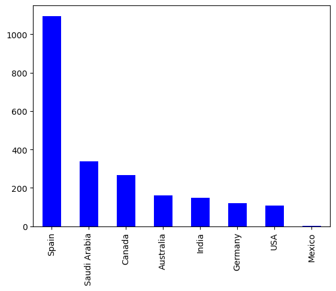

```python
data.Country.value_counts().plot(kind = 'bar',color = 'blue')
```

Sales by country

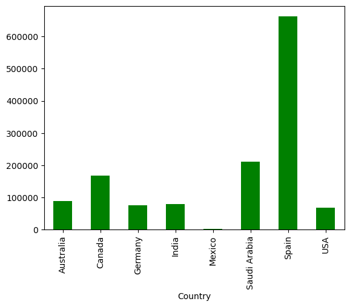

```python
data.groupby('Country')['Total_sales'].sum().plot(kind='bar',color = 'green')
```

Sales by marital status

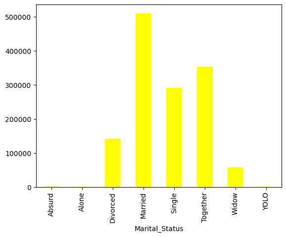

```python
data.groupby('Marital_Status')['Total_sales'].sum().plot(kind='bar',color= 'yellow')
```

Sales by numner of children per family

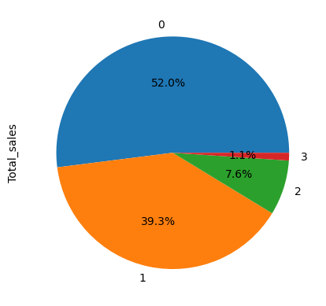

```python
data.groupby('Total_Children')['Total_sales'].sum().plot(kind='pie',autopct = '%1.1f%%')
```

Product with the sales information

```python
print('Total_all_Sales',data['Total_sales'].sum())
print('Sales_from_Fish',data['Fish_Sales'].sum())
print('Sales_from_Sweet',data['Sweet_sales'].sum())
print('Sales_from_Gold',data['Gold_sales'].sum())
print('Sales_from_Wine',data['Wine_Sales'].sum())
print('Sales_from_Fruit',data['Fruit_sales'].sum())
print('Sales_from_Meat',data['Meat sales'].sum())
```

```
Total_all_Sales 1356988
Sales_from_Fish 84057
Sales_from_Sweet 60621
Sales_from_Gold 98609
Sales_from_Wine 680816
Sales_from_Fruit 58917
Sales_from_Meat 373968
```

```python
data.head(5)
```

|  | ID | Year_Birth | Education | Marital_Status | Salary | Kidhome | Teenhome | Dt_Customer | Month | last_pur_days | ... | Gold_sales | NumWebPurchases | NumCatalogPurchases | NumStorePurchases | NumWebVisitsMonth | Country | Complain | Age | Total_Children | Total_sales |
| --- | --- | --- | --- | --- | --- | --- | --- | --- | --- | --- | --- | --- | --- | --- | --- | --- | --- | --- | --- | --- | --- |
| 0 | 1826 | 1970 | Graduation | Divorced | 84835.0 | 0 | 0 | 6/16/2014 | June | 0 | ... | 218 | 4 | 4 | 6 | 1 | Spain | 0 | 43 | 0 | 1190 |
| 1 | 1 | 1961 | Graduation | Single | 57091.0 | 0 | 0 | 6/15/2014 | June | 0 | ... | 37 | 7 | 3 | 7 | 5 | Canada | 0 | 52 | 0 | 577 |
| 2 | 10476 | 1958 | Graduation | Married | 67267.0 | 0 | 1 | 5/13/2014 | May | 0 | ... | 30 | 3 | 2 | 5 | 2 | USA | 0 | 55 | 1 | 251 |
| 3 | 1386 | 1967 | Graduation | Together | 32474.0 | 1 | 1 | 5/11/2014 | May | 0 | ... | 0 | 1 | 0 | 2 | 7 | Australia | 0 | 46 | 2 | 11 |
| 4 | 5371 | 1989 | Graduation | Single | 21474.0 | 1 | 0 | 4/8/2014 | April | 0 | ... | 34 | 3 | 1 | 2 | 7 | Spain | 0 | 24 | 1 | 91 |

5 rows × 25 columns

The findings from the above analysis includes:

1.The biggest sales of the year is from Spain,the company should look for ways to invest more in the country,if possible the company should reduce the cost of advertising and invest it in the country like Mexico where there are low sales

4.The least sales come from the family with the highest number of children,which means the company product does not appeal enough to large family as the relationship shows the higher the number of children per family the lower the sales.

5.The product with highest sales for the year is Wine.